# R Notebook

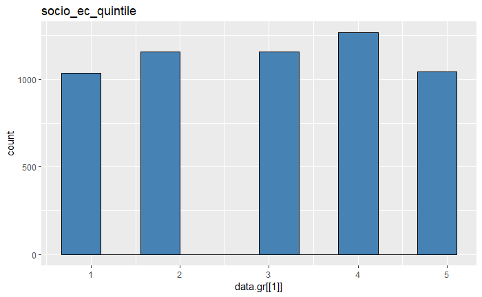

[figure not shown]

`r`r field.nr <- 13 data.gr <- hogares.clean[field.nr] ggplot(data.gr, aes(data.gr[[1]],fill=data.gr[[1]])) + stat_count()+ggtitle(english_labels[field.nr])+ theme(axis.text.x = element_text(angle = 30, hjust = 1))+scale_fill_brewer( type = , palette = 1, direction = 1, aesthetics = )

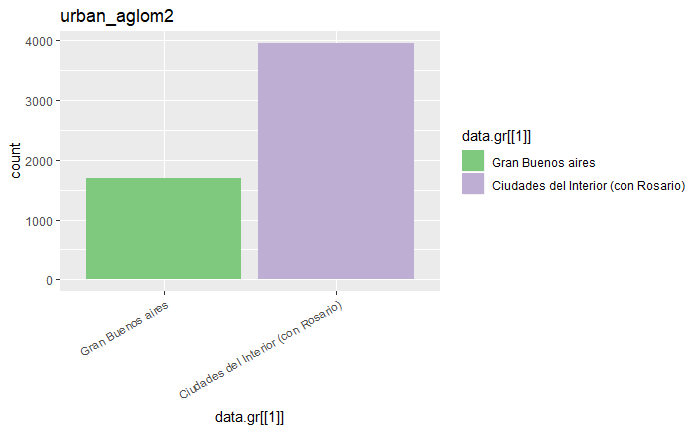

`r`r field.nr <- 14 data.gr <- hogares.clean[field.nr] ggplot(data.gr, aes(data.gr[[1]],fill=data.gr[[1]])) + stat_count()+ggtitle(english_labels[field.nr])+ theme(axis.text.x = element_text(angle = 30, hjust = 1))+scale_fill_brewer( type = , palette = 1, direction = 1, aesthetics = )

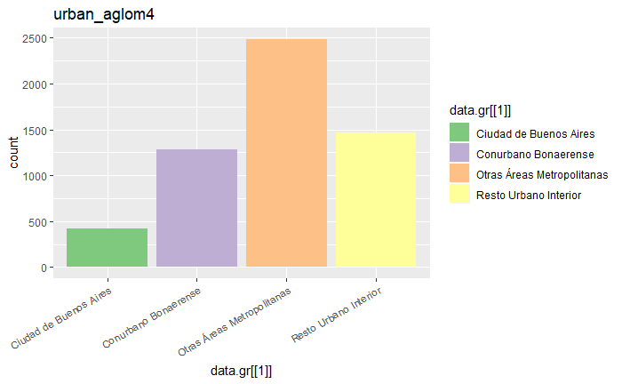

`r`r field.nr <- 15 data.gr <- hogares.clean[field.nr] ggplot(data.gr, aes(data.gr[[1]],fill=data.gr[[1]])) + stat_count()+ggtitle(english_labels[field.nr])+ theme(axis.text.x = element_text(angle = 30, hjust = 1))+scale_fill_brewer( type = , palette = 1, direction = 1, aesthetics = )

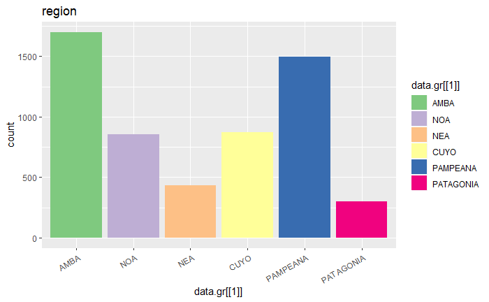

`r`r field.nr <- 16 data.gr <- hogares.clean[field.nr] ggplot(data.gr, aes(data.gr[[1]],fill=data.gr[[1]])) + stat_count()+ggtitle(english_labels[field.nr])+ theme(axis.text.x = element_text(angle = 30, hjust = 1))+scale_fill_brewer( type = , palette = 1, direction = 1, aesthetics = )

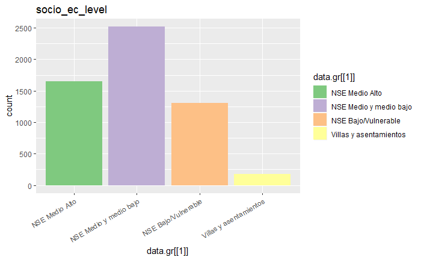

`r`r field.nr <- 17 data.gr <- hogares.clean[field.nr] ggplot(data.gr, aes(data.gr[[1]],fill=data.gr[[1]])) + stat_count()+ggtitle(english_labels[field.nr])+ theme(axis.text.x = element_text(angle = 30, hjust = 1))+scale_fill_brewer( type = , palette = 1, direction = 1, aesthetics = )

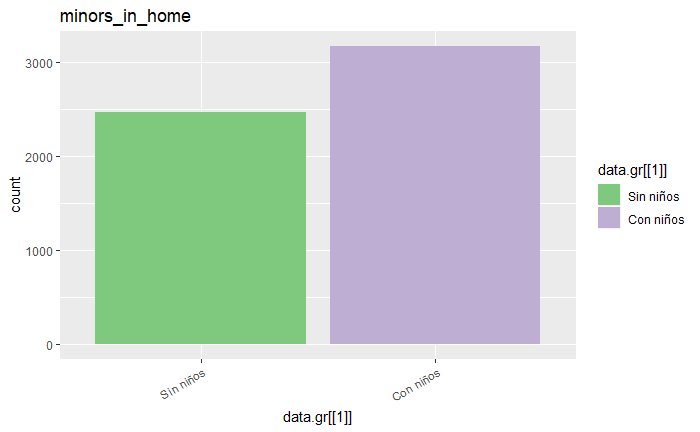

`r`r field.nr <- 18 data.gr <- hogares.clean[field.nr] ggplot(data.gr, aes(data.gr[[1]],fill=data.gr[[1]])) + stat_count()+ggtitle(english_labels[field.nr])+ theme(axis.text.x = element_text(angle = 30, hjust = 1))+scale_fill_brewer( type = , palette = 1, direction = 1, aesthetics = )

[figure not shown]

`r`r field.nr <- 19 data.gr <- hogares.clean[field.nr] ggplot(data.gr, aes(data.gr[[1]],fill=data.gr[[1]])) + stat_count()+ggtitle(english_labels[field.nr])+ theme(axis.text.x = element_text(angle = 30, hjust = 1))+scale_fill_brewer( type = , palette = 3, direction = 1, aesthetics = )

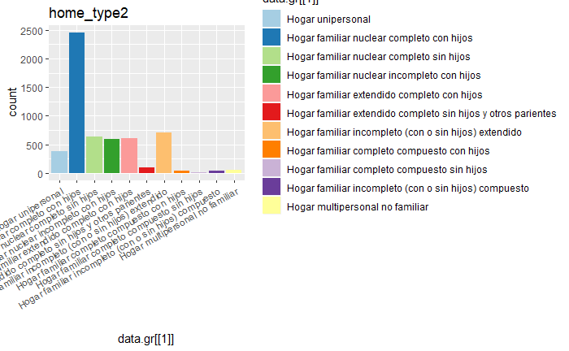

`r`r field.nr <- 20 data.gr <- hogares.clean[field.nr] ggplot(data.gr, aes(data.gr[[1]],fill=data.gr[[1]])) + stat_count()+ggtitle(english_labels[field.nr])+ theme(axis.text.x = element_text(angle = 30, hjust = 1))+scale_fill_brewer( type = , palette = 3, direction = 1, aesthetics = )

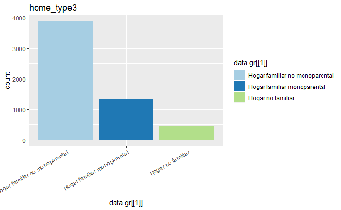

`r`r field.nr <- 21 data.gr <- hogares.clean[field.nr] ggplot(data.gr, aes(data.gr[[1]],fill=data.gr[[1]])) + stat_count()+ggtitle(english_labels[field.nr])+ theme(axis.text.x = element_text(angle = 30, hjust = 1))+scale_fill_brewer( type = , palette = 3, direction = 1, aesthetics = )

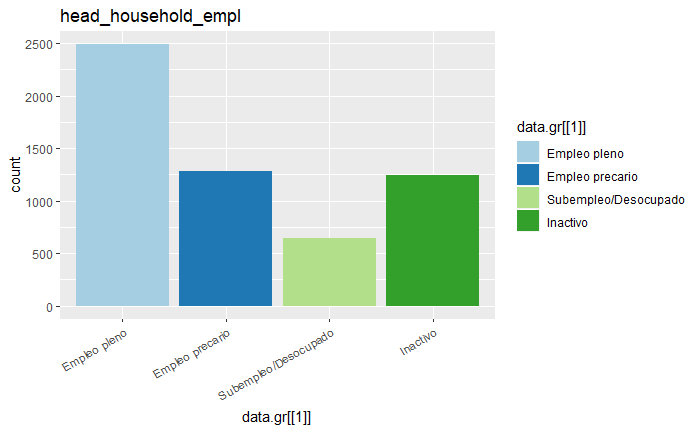

`r`r field.nr <- 22 data.gr <- hogares.clean[field.nr] ggplot(data.gr, aes(data.gr[[1]],fill=data.gr[[1]])) + stat_count()+ggtitle(english_labels[field.nr])+ theme(axis.text.x = element_text(angle = 30, hjust = 1))+scale_fill_brewer( type = , palette = 3, direction = 1, aesthetics = )

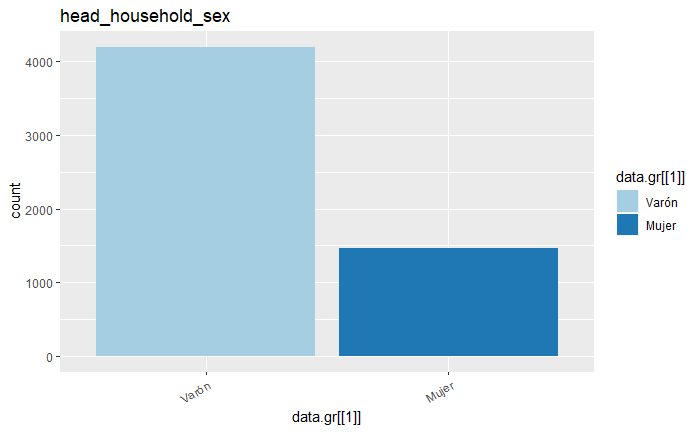

`r`r field.nr <- 23 data.gr <- hogares.clean[field.nr] ggplot(data.gr, aes(data.gr[[1]],fill=data.gr[[1]])) + stat_count()+ggtitle(english_labels[field.nr])+ theme(axis.text.x = element_text(angle = 30, hjust = 1))+scale_fill_brewer( type = , palette = 3, direction = 1, aesthetics = )

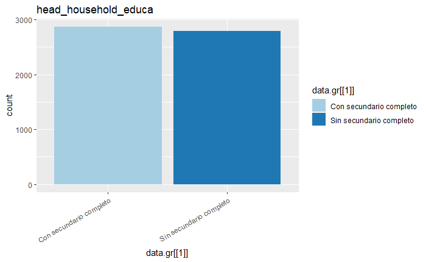

`r`r field.nr <- 24 data.gr <- hogares.clean[field.nr] ggplot(data.gr, aes(data.gr[[1]],fill=data.gr[[1]])) + stat_count()+ggtitle(english_labels[field.nr])+ theme(axis.text.x = element_text(angle = 30, hjust = 1))+scale_fill_brewer( type = , palette = 3, direction = 1, aesthetics = )

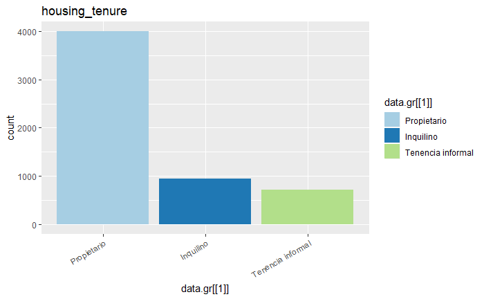

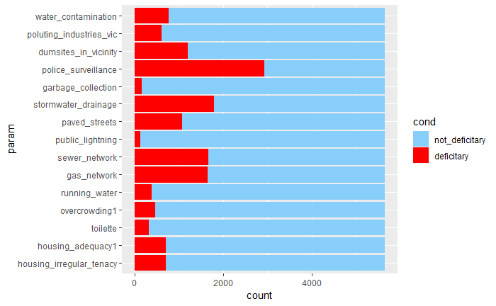

`r`r ggplot(deficit_matrix[c(31:60),], aes(fill=forcats::fct_rev(cond), y=count, x=param)) + geom_bar(stat=)+coord_flip()+scale_fill_manual(,values = c( = , _deficitary = ))

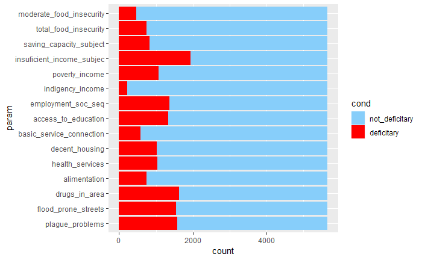

`r`r ggplot(deficit_matrix[c(61:90),], aes(fill=forcats::fct_rev(cond), y=count, x=param)) + geom_bar(stat=)+coord_flip()+scale_fill_manual(,values = c( = , _deficitary = ))

[figure not shown]

`r`r nrFields <- length(poverty.binary.df) chisq.table <- as.data.frame(mapply(function(x, y) chisq.test(x, y)$statistic ,poverty.binary.df,rep(poverty.binary.df[1],nrFields)))

```
Chi-squared approximation may be incorrect
```

`r`r names(chisq.table)<-names(poverty.binary.df[1]) for (field in c(2:nrFields)){ chisq.newcol <- as.data.frame(mapply(function(x, y) chisq.test(x, y)$statistic ,poverty.binary.df,rep(poverty.binary.df[field],nrFields))) names(chisq.newcol)<-names(poverty.binary.df[field]) chisq.table <- cbind.data.frame(chisq.table,chisq.newcol) }

[output not shown]

`r`r hogares.clean[poverty.binary] <- poverty.binary.df hogares.factor <- hogares.clean[unlist(sapply(hogares.clean,class))==] hogares.factor <- hogares.factor[-1] #remove the survey year